# Homework #3

Your Name

## Palmer Penguins

In this homework we will use the `penguins` data set. This data set is part of the `palmerpenguins` package. You can load the data set by executing the command:

```r
data(penguins, package="palmerpenguins")
```

If the command above throws an error message about the package not found, make sure to install the `palmerpenguins` package on your machine.

The information in the penguins data is collected by several antarctic research teams, who took body measurements of different types of penguins in three different locations. See `?penguins` for a description of all of the variables and a bit of the scientific background of this data.

1. Download the RMarkdown file with these homework instructions to use as a template for your work. Make sure to replace “Your Name” in the YAML with your name.

For all of the questions, we would like to see your answer based on R code, i.e. for each question include a code chunk with the relevant code AND write the answer to the question based on the code results in plain English.

2. How many penguins are part of the studies? What type doe the variables have that were collected? Show your code.

There are 344 penguins in the dataset. The dataset contains various variables, including factors, numerics, and integers.

```r
# Calculate the number of penguins
n_penguins <- nrow(penguins)

# Display the structure of the dataset
str(penguins)
```

```
## tibble [344 × 8] (S3: tbl_df/tbl/data.frame)
##  $ species          : Factor w/ 3 levels "Adelie","Chinstrap",..: 1 1 1 1 1 1 1 1 1 1 ...
##  $ island           : Factor w/ 3 levels "Biscoe","Dream",..: 3 3 3 3 3 3 3 3 3 3 ...
##  $ bill_length_mm   : num [1:344] 39.1 39.5 40.3 NA 36.7 39.3 38.9 39.2 34.1 42 ...
##  $ bill_depth_mm    : num [1:344] 18.7 17.4 18 NA 19.3 20.6 17.8 19.6 18.1 20.2 ...
##  $ flipper_length_mm: int [1:344] 181 186 195 NA 193 190 181 195 193 190 ...
##  $ body_mass_g      : int [1:344] 3750 3800 3250 NA 3450 3650 3625 4675 3475 4250 ...
##  $ sex              : Factor w/ 2 levels "female","male": 2 1 1 NA 1 2 1 2 NA NA ...
##  $ year             : int [1:344] 2007 2007 2007 2007 2007 2007 2007 2007 2007 2007 ...
```

3. How does the length (`bill_length_mm`) of a penguin’s beak relate to its depth (`bill_depth_mm`)? Use the `ggplot2` package to show a chart, describe the relationship in words. Describe the structure and propose a follow-up. (3 sentences: structure of the plot, what do you see, follow-up).

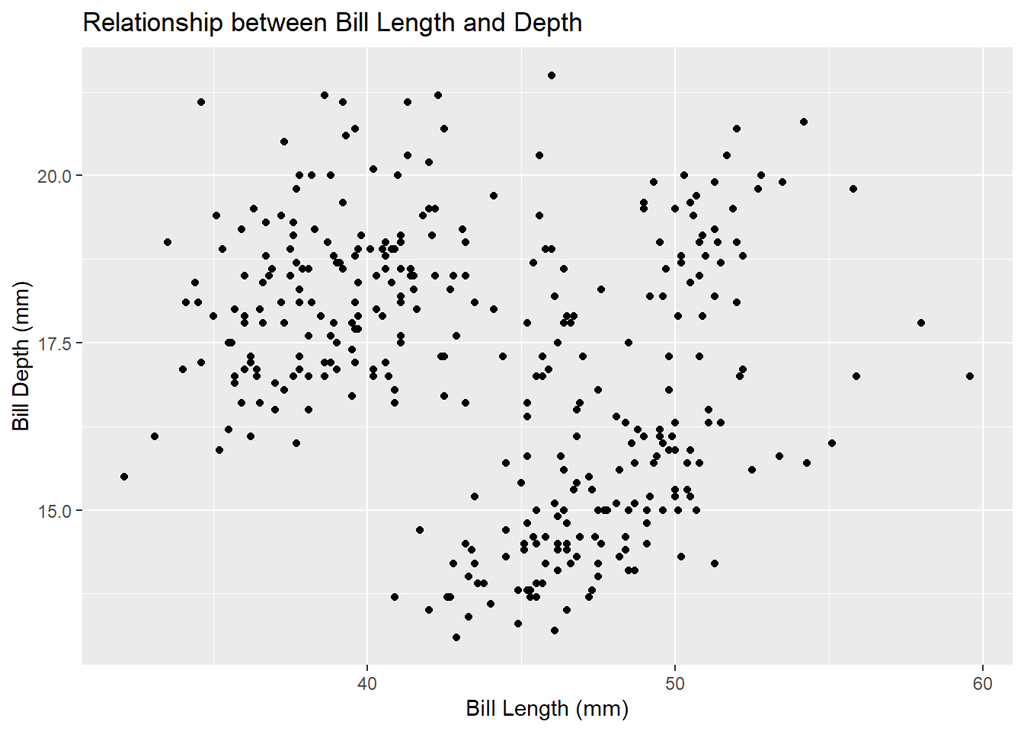

```r
# Load the ggplot2 package
library(ggplot2)

# Create a scatterplot
scatter_plot <- ggplot(penguins, aes(x = bill_length_mm, y = bill_depth_mm)) +
  geom_point() +
  labs(x = "Bill Length (mm)", y = "Bill Depth (mm)", title = "Relationship between Bill Length and Depth")

# Print the scatterplot
scatter_plot
```

When we map “species” to color, we see that different penguin species also form distinct clusters. Each species has a characteristic range of bill lengths and depths. This color mapping further informs us that bill morphology is species-specific.